# 1. Import Libraries With Their Accronyms

```python
import numpy as np
import pandas as pd
import matplotlib as map
import matplotlib.pyplot as plt
import scipy as sc
import statistics as stat
from scipy.stats import binom
import seaborn as sns
```

# 2. Calculating Normal Distribution

## (1) Creating normal distribution

To calculate probability of specific value to happen, we need to identify:

1. **Mean**: m
2. **Standard Deviation**: sd
3. **Number of Samples**: n

Greer will guarantee that its engines will provide a certain amount of lifetime flight hours subject to the airline purchasing a preventive-maintenance service plan that is also provided by Greer.

With proper maintenance service, their engine’s lifetime flight hours achieved is normally distributed, mean=36500, SD=5000.

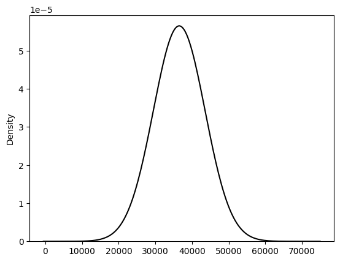

```python
# Create data: Assuming randomly selected and normaly distributed
m=36500
sd=5000
n=1000000
value = np.random.normal(loc=mean,scale=sd,size=n)
points = sns.kdeplot(value, fill=False, bw_method=1.0, color='black').get_lines()[0].get_data()
```

### Question1.

They want to promote that once they purchase the maintenance service pack, then you don’t need to replace your engine until you use it for 40,000 hrs by XX%.

So, Greer would like to know what percentage of its aircraft engines will be expected to last more than 40,000hrs. That is, what is the probability that the aircraft lifetime flight hours x will exceed 40,000.

```python
# Calculating a probability that the aircraft lifetime flight hours x will exceed 40,000.
cum=stat.NormalDist(mu=36500, sigma=5000).cdf(40000)
print("A probability that the aircraft lifetime flight hours will exceed 40,000 is", round(1-cum,4)*100,"%")
```

```
A probability that the aircraft lifetime flight hours will exceed 40,000 is 24.2 %
```

```python
x=points[0]
y=points[1]
```

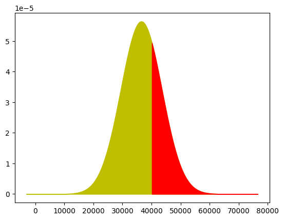

```python
plt.fill_between(x, y, color='y')
plt.fill_between(x, y, where = (x>=40000), color='r')
```

### Question2.

Now Greer is considering a guarantee that will provide a discount on a replacement aircraft engine if the original engine does not meet the lifetime-flight-hour guarantee.

How many lifetime flight hours should Greer guarantee if Greer wants no more than 10% of aircraft engines to be eligible for the discount guarantee?

```python
inv=stat.NormalDist(mu=m, sigma=sd).inv_cdf(0.1)
print("Lifetime flight hours that can guarantee that no more than 10% of its engines will be eligible for the discount promotion is", round(inv,0),"flight hours.")
inv
```

```
Lifetime flight hours that can guarantee that no more than 10% of its engines will be eligible for the discount promotion is 30092.0 flight hours.
```

```
30092.242172276994
```

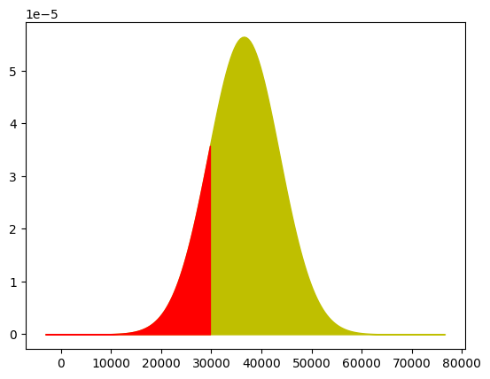

```python
plt.fill_between(x, y, color='y')
plt.fill_between(x, y, where = (x<=30092), color='r')
```